# Se apresentando

Maxwel Coura Oliveira

> Leia até o passo 6! E observe que há um arquivo que precisa ser entregue na primeira aula!

# 1 Visão geral

Este documento irá guiá-lo através das etapas para instalar e usar R, um ambiente de software gratuito e de código aberto para computação estatística e gráficos.

- O que é R?

**R** é o nome da própria linguagem de programação, baseada no S da Bell Labs, que os usuários acessam por meio de um interpretador de linha de comando (`>`)

- O que é RStudio?

**RStudio** é uma poderosa interface de usuário e conveniente que permite acessar a linguagem de programação R junto com vários outros recursos que aprimoram a funcionalidade (e a sanidade).

Nosso objetivo final é fazer você olhar para uma tela como esta:

[figure not shown]

- O que é Github?

O **Github** é um site que fornece hospedagem para desenvolvimento de software e controle de versão usando Git. O Github não é um requisito para usar o R/Rstudio mas otimiza o uso do programa e vamos usar durante nosso curso.

# 2 Instale R

Instale o R a partir de [CRAN, The Comprehensive R Archive Network](https://cran.rstudio.com). Escolha uma **distribuição binária pré-compilada** para seu sistema operacional.

- Se precisar de mais ajuda, confira um dos vídeos a seguir (cortesia de Roger Peng em Johns Hopkins Biostatistics):
  - [Instalando o R em um mac](https://www.youtube.com/watch?v=Icawuhf0Yqo&feature=youtu.be)
  - [Instalando o R no Windows](https://www.youtube.com/watch?v=mfGFv-iB724&feature=youtu.be)
- Se precisar de mais ajuda, leia este [guia passo a passo](https://beckmw.files.wordpress.com/2014/09/r_install_guide.pdf), incluindo capturas de tela.

## 2.1 Checando

Inicie o R. Você deve ver um console com um interpretador de linha de comando (`>`). Feche o R.

# 3 Instale o RStudio

Instale a edição gratuita de código aberto do RStudio: http://www.rstudio.com/products/rstudio/download/

O RStudio fornece uma interface poderosa de usuário para R, chamada de *ambiente de desenvolvimento integrado (IDE)*. RStudio inclui:

- um console (a interface de linha de comando padrão: `>`),
- um editor de realce de sintaxe que oferece suporte à execução direta de código e
- Ferramentas para plotagem, histórico, depuração e gerenciamento de espaço de trabalho.

## 3.1 Checando

- Posicione o cursor onde você vê `>` e digite `x <- 2 + 2`, pressione Enter ou Return, digite `x` e pressione Enter / Return novamente.
- Se `[1] 4` for impresso na tela, você instalou com sucesso R e RStudio e pode prosseguir com a instalação de pacotes.

# 4 Instale o Github

Instale o Github no site https://github.com. Crie uma conta, use um e-mail profissional. Não baixe nenhum software. Após a conta criada no site, saia e feche o site. Não vai precisar do Github para essa atividade.

# 5 Instalando pacotes

A versão de R que você acabou de baixar é considerada a base R, o que fornece computação estatística e recursos gráficos bons, mas básicos. Para superpoderes analíticos e gráficos, você precisará instalar pacotes (`packages`) complementares, que são escritos pelo usuário, para estender/expandir seus recursos de R. Os pacotes podem residir em um de dois lugares:

- Eles podem ser cuidadosamente selecionados pelo CRAN (que envolve um processo completo de submissão e revisão) e, portanto, são fáceis de instalar usando `install.packages("name_of_package", dependencies = TRUE)`.
- Como alternativa, eles podem estar disponíveis no [GitHub](https://github.com). Para baixar esses pacotes, você primeiro precisa instalar o pacote `devtools`.

```r
install.packages("devtools")
library(devtools)
install_github("nome_do_pacote")
```

Posicione seu cursor no console novamente (onde você digitou pela última vez `x` e`[4]` impresso na tela). Você pode usar o primeiro método mencionado acima para instalar os seguintes pacotes diretamente do CRAN, todos os quais usaremos:

- [`dplyr`,](http://dplyr.tidyverse.org)
- [`ggplot2`,](http://ggplot2.tidyverse.org)
- [`babynames`](https://github.com/hadley/babynames)

Você também pode baixar tudo de uma vez:

```r
install.packages(c("dplyr", "ggplot2", "babynames"),
                 dependencies = TRUE)
```

**Cuidado:** Devemos apresentar formalmente o comando de combinação, [`c()`](http://stat.ethz.ch/R-manual/R-patched/library/base/html/c.html), usado acima. Você vai usar isso com frequência, sempre que quiser combinar coisas em um vetor.

```r
c("oi", "meu", "nome", "e", "maxwel")
```

```
[1] "oi"     "meu"    "nome"   "e"      "maxwel"
```

```r
c(1:3, 20, 50)
```

```
[1]  1  2  3 20 50
```

Cuidado com o uso de citações com cuidado com os pacotes.

- Para *instalar* um pacote (`package`), você coloca o nome do pacote entre aspas como em `install.packages("nome_do_pacote")`.
- Para *usar* um pacote já instalado, você deve carregá-lo primeiro, como em `library(nome_do_pacote)`. Você só precisa fazer isso uma vez por sessão RStudio.
- Se você quiser *ajuda*, não são necessárias aspas: `help(nome_do_pacote)` ou `?nome_do_pacote`.
- Se você quiser a *citação* de um pacote (e você deve dar crédito onde o crédito é devido), pergunte a R como em `citação("nome_do_pacote")`.

```r
install.packages("dplyr", dependencies = TRUE)
library(dplyr)
help("dplyr")
```

```r
citation("ggplot2")
```

```
  H. Wickham. ggplot2: Elegant Graphics for Data Analysis.
  Springer-Verlag New York, 2016.

A BibTeX entry for LaTeX users is

  @Book{,
    author = {Hadley Wickham},
    title = {ggplot2: Elegant Graphics for Data Analysis},
    publisher = {Springer-Verlag New York},
    year = {2016},
    isbn = {978-3-319-24277-4},
    url = {https://ggplot2.tidyverse.org},
  }
```

**Cuidado:** O R **diferencia maiúsculas de minúsculas**, então `?dplyr` funciona, mas`?Dplyr` não. Da mesma forma, uma variável chamada `A` é diferente de`a`. Assim como devemos evitar acentos (ex., à, õ, é)

# 6 Faça um gráfico de nome

Abra um novo script R no RStudio indo em `File -> New File -> R Script`. Para esta primeira incursão em R, vou lhe dar o código, então sente-se e relaxe e fique à vontade para copiar e colar meu código com alguns pequenos ajustes.

Primeiro carregue os pacotes:

```r
library(babynames) # contém os dados reais
library(dplyr) # para manipulação de dados
library(ggplot2) # para plotar os dados
```

A seguir, seguiremos [práticas recomendadas para inspecionar um conjunto de dados recém-lido](https://cran.r-project.org/doc/contrib/de_Jonge+van_der_Loo-Introduction_to_data_cleaning_with_R.pdf). Além disso, consulte [“O que eu faço quando obtenho um novo conjunto de dados conforme informado por meio de tweets”](http://simplystatistics.org/2014/06/13/what-i-do-when-i-get-a-%20new-data-set-as-told-through-tweets%20/) para mais ideias sobre como explorar um novo conjunto de dados. Aqui estão alguns comandos críticos para obter uma visão geral de alto nível de seu conjunto de dados recém-lido em R. Vamos chamá-lo de dizer olá para seu conjunto de dados:

```r
glimpse(babynames) # dplyr
```

```
Rows: 1,924,665
Columns: 5
$ year <dbl> 1880, 1880, 1880, 1880, 1880, 1880, 1880, 1880, 1880, 1880, 1880…
$ sex  <chr> "F", "F", "F", "F", "F", "F", "F", "F", "F", "F", "F", "F", "F",…
$ name <chr> "Mary", "Anna", "Emma", "Elizabeth", "Minnie", "Margaret", "Ida"…
$ n    <int> 7065, 2604, 2003, 1939, 1746, 1578, 1472, 1414, 1320, 1288, 1258…
$ prop <dbl> 0.07238359, 0.02667896, 0.02052149, 0.01986579, 0.01788843, 0.01…
```

```r
head(babynames) # base R
```

```
# A tibble: 6 x 5
   year sex   name          n   prop
  <dbl> <chr> <chr>     <int>  <dbl>
1  1880 F     Mary       7065 0.0724
2  1880 F     Anna       2604 0.0267
3  1880 F     Emma       2003 0.0205
4  1880 F     Elizabeth  1939 0.0199
5  1880 F     Minnie     1746 0.0179
6  1880 F     Margaret   1578 0.0162
```

```r
tail(babynames) # same
```

```
# A tibble: 6 x 5
   year sex   name       n       prop
  <dbl> <chr> <chr>  <int>      <dbl>
1  2017 M     Zyhier     5 0.00000255
2  2017 M     Zykai      5 0.00000255
3  2017 M     Zykeem     5 0.00000255
4  2017 M     Zylin      5 0.00000255
5  2017 M     Zylis      5 0.00000255
6  2017 M     Zyrie      5 0.00000255
```

```r
names(babynames) # same
```

```
[1] "year" "sex"  "name" "n"    "prop"
```

```r
maxwel <- babynames %>%
  filter(name == "Maxwel" | name == "Maxwell") %>%
  filter(sex == "M")
```

- A primeira parte cria um novo conjunto de dados chamado `maxwel` que é uma cópia do conjunto de dados`babynames` - o `%>%` diz que estamos fazendo outras coisas nele.
- A segunda parte filtra (`filter`) nossos`nomes de bebês` para manter apenas as linhas em que o `nome` é Maxwel ou Maxwell (leia`|`como *" ou "*.)
- A terceira parte filtra aplica outro filtro (`filter`) para manter apenas aqueles onde o sexo é masculino.

Vamos verificar os dados.

```r
maxwel
```

```
# A tibble: 161 x 5
    year sex   name        n      prop
   <dbl> <chr> <chr>   <int>     <dbl>
 1  1880 M     Maxwell     9 0.0000760
 2  1882 M     Maxwell     6 0.0000492
 3  1883 M     Maxwell    10 0.0000889
 4  1884 M     Maxwell     8 0.0000652
 5  1885 M     Maxwell     8 0.000069
 6  1886 M     Maxwell     6 0.0000504
 7  1887 M     Maxwell     7 0.0000640
 8  1888 M     Maxwell     7 0.0000539
 9  1889 M     Maxwell    11 0.0000924
10  1890 M     Maxwell    15 0.000125
# … with 151 more rows
```

```r
glimpse(maxwel)
```

```
Rows: 161
Columns: 5
$ year <dbl> 1880, 1882, 1883, 1884, 1885, 1886, 1887, 1888, 1889, 1890, 1891…
$ sex  <chr> "M", "M", "M", "M", "M", "M", "M", "M", "M", "M", "M", "M", "M",…
$ name <chr> "Maxwell", "Maxwell", "Maxwell", "Maxwell", "Maxwell", "Maxwell"…
$ n    <int> 9, 6, 10, 8, 8, 6, 7, 7, 11, 15, 7, 10, 13, 8, 13, 16, 21, 16, 1…
$ prop <dbl> 0.00007601, 0.00004917, 0.00008891, 0.00006518, 0.00006900, 0.00…
```

Novamente, se você tiver uma saída (output) aparentemente normal, prossiga para plotar os dados!

```r
plot <- ggplot(maxwel, aes(x = year,
                           y = prop,
                           group = name,
                           color = name)) +
  geom_line()
```

Agora, se você fez isso direito, não verá seu gráfico! Como salvamos o `ggplot` com um nome (`plot`), R apenas salvou o objeto para você. Mas verifique o painel superior direito do RStudio novamente: em `Values` você deve ver o `plot`, então está lá, você só precisa pedir por ele. Veja como:

[figure not shown]

```r
plot
```

# 7 Faça um novo gráfico de nome

Edite meu código acima para criar um novo conjunto de dados (`dataset`). Escolha 2 nomes para comparar a popularidade de cada um (podem ser grafias diferentes do seu próprio nome, como eu fiz, mas você pode escolher quaisquer 2 nomes que estejam presentes no conjunto de dados). Faça o novo gráfico, alterando o nome do primeiro argumento `maxwel` em`ggplot()` para o nome do seu novo conjunto de dados (dataset).

## 7.1 Salvar e compartilhar

Salve seu trabalho para que você possa compartilhar seu gráfico favorito conosco. Você não gostará da aparência do seu gráfico se passar o mouse sobre `Export` e `Save as` (salvá-lo). Em vez disso, use o comando `ggplot2` para salvar um gráfico com padrões razoáveis:

```r
help(ggsave)
```

```r
ggsave("max_oliveira.pdf", plot) # por favor, mude o nome do arquivo!
```

Deixe o gráfico pronto para a aula do dia 21/09.

# 8 Outros projetos legais de `babynames`

- Julia Silge *‘My Baby Boomer Name Might Have Been “Debbie”’*: https://juliasilge.com/blog/my-baby-boomer-name/
  - Use Julia’s Shiny app: https://juliasilge.shinyapps.io/PredictNamesApp/

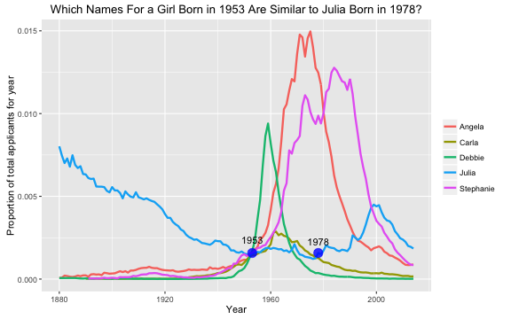

- Hilary Parker: Hilary: The Most Poisoned Baby Name in US History: https://hilaryparker.com/2013/01/30/hilary-the-most-poisoned-baby-name-in-us-history/

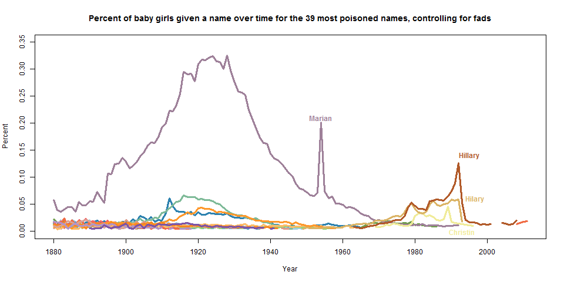